# Untitled

Amelia Ritger

6/30/2020

# import packages

```r
library(tidyverse) # data wrangling & vizn
library(here) # for reproducibility!
library(chron) # working with times/dates
library(lubridate) # working with times/dates
library(naniar) # working with missing data
library(ggridges) # makes pretty geom_ridge plots

#For ts stuff:
library(tsibble)
library(fable)
library(fabletools)
library(feasts)
library(forecast)
```

# metadata - this is a simple csv I built with the file names and associated information; it’ll make importing/wrangling all the files in one step a bit easier in Part 1

```r
metadata <- read_csv(here("bottom-temp", "csv", "lter-file-names.csv"))
```

# this function imports each of the 5 files, cleans up the data and keeps only the required variables (there are way too many columns to deal with otherwise)

```r
import_temp_files <- function(file_name_csv, site){ #file_name_csv and site are generic terms
  read_csv(here::here("bottom-temp", "csv", file_name_csv), col_names = TRUE, col_types = cols(.default = col_character())) %>%
  select(year, month, day, decimal_time, Temp_bot, Temp_top, Temp_mid) %>%
  unite(date, year, month, day, sep = "-", remove = FALSE) %>%
  mutate(time = times(as.numeric(decimal_time))) %>%
  unite(date_time, date, time, sep = " ") %>%
  select(date_time, year, month, day, Temp_bot, Temp_top, Temp_mid) %>%
  mutate(date_time = as.POSIXct(date_time, "%Y-%m-%d %H:%M:%S", tz = "GMT"),
         year = as.factor(year),
         month = as.factor(month),
         day = as.numeric(day),
         Temp_top = as.numeric(Temp_top),
         Temp_mid = as.numeric(Temp_mid),
         Temp_bot = as.numeric(Temp_bot),
         site = rep(site)) %>%
  replace_with_na(replace = list(Temp_bot = 9999)) %>%
  replace_with_na(replace = list(Temp_top = 9999)) %>%
  replace_with_na(replace = list(Temp_mid = 9999))
}
```

# initialize empty df to fill with cleaned data

```r
temp_data <- data.frame(date_time = as.Date(character()),
                        year = factor(),
                        month = factor(),
                        day = numeric(),
                        site = as.character(),
                        Temp_bot = numeric(),
                        Temp_top = numeric(),
                        Temp_mid = numeric())
```

# for loop reads in/wrangles all files using the import_temp_files() function above

```r
for (row in 1:nrow(metadata)) {
  data_row <- metadata[row,]
  file_name_csv <- paste(as.character(data_row[, 1]),".csv", sep="")
  print(file_name_csv) #self check step
  site <- as.character(data_row[,2])
  print(site)
  table <- import_temp_files(file_name_csv, site)
  temp_data <- rbind(temp_data, table)
}
```

```
## [1] "alegria_mooring_ale_20171208.csv"
## [1] "ALE"
## [1] "arroyoquemado_mooring_arq_20171218.csv"
## [1] "ARQ"
## [1] "carpinteria_mooring_car_20171218.csv"
## [1] "CAR"
## [1] "mohawk_mooring_mko_20171218.csv"
## [1] "MKO"
## [1] "naples_mooring_nap_20171218.csv"
## [1] "NAP"
```

# Save this combinded df as a csv file to work with in other scripts/to avoid having to run the for loop over and over again

```r
write.csv(temp_data, here("bottom-temp", "amelia", "all_bottom_temps_2005_2020.csv"), row.names = FALSE)
```

## Sam’s plots

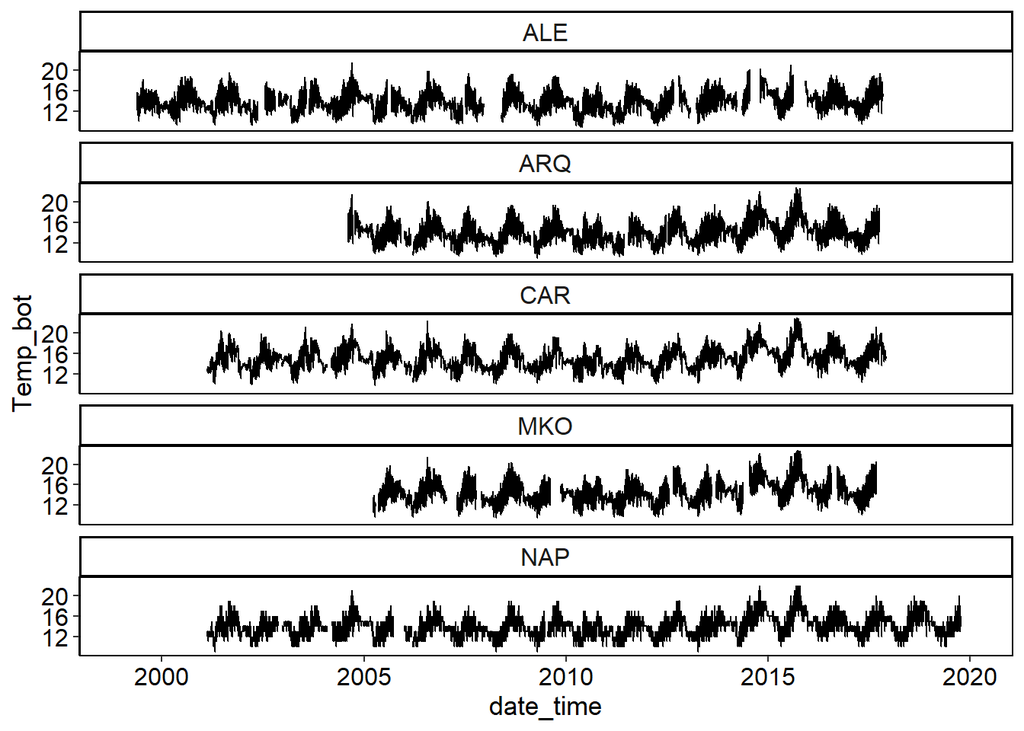

```r
ggplot(temp_data, aes(x = date_time, y = Temp_bot)) +
  geom_line() +
  #geom_hline(yintercept = 11, linetype = "dashed", color = "red") +
  #geom_hline(yintercept = 16, linetype = "dashed", color = "red") +
  #geom_hline(yintercept = 21, linetype = "dashed", color = "red") +
  facet_wrap(~site, ncol = 1) +
  theme_classic() +
  theme(axis.text = element_text(color = "black", size = 12),
        axis.title = element_text(size = 13),
        plot.title = element_text(size = 20, face = "bold"),
        panel.border = element_rect(colour = "black", fil = NA, size = 0.7),
        strip.background = element_rect(fill = "white"),
        strip.text = element_text(size = 12),
        legend.position = "none")
```

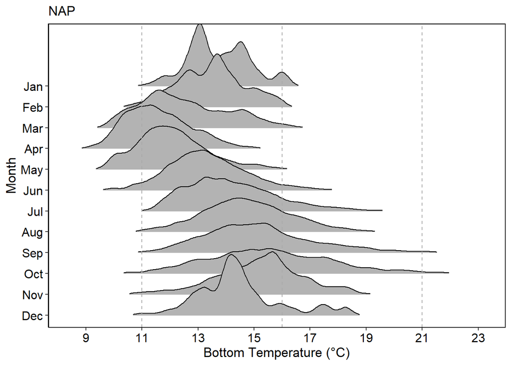

```r
##############################
# filter out years that don't have data for some sites, add month abbreviations and set factor levels
##############################

cleaned_temp_data <- temp_data %>%
  #filter(!year %in% c("1999", "2000", "2001", "2002", "2003", "2004")) %>% # remove years that we don't have good data for
  mutate(month = as.factor(month), # there's prob a shortcut for this but I was too lazy to figure it out
         month_name = case_when(
            month == "1" ~ "Jan",
            month == "2" ~ "Feb",
            month == "3" ~ "Mar",
            month == "4" ~ "Apr",
            month == "5" ~ "May",
            month == "6" ~ "Jun",
            month == "7" ~ "Jul",
            month == "8" ~ "Aug",
            month == "9" ~ "Sep",
            month == "10" ~ "Oct",
            month == "11" ~ "Nov",
            month == "12" ~ "Dec"
        )
      ) %>%
  mutate(month_name = fct_relevel(month_name, "Dec", "Nov", "Oct", "Sep", "Aug", # get months in correct order
                                  "Jul", "Jun", "May", "Apr", "Mar", "Feb", "Jan")) %>%
  group_by(month_name)

##############################
# identify all unique sites to plot
##############################

unique_sites <- unique(temp_data$site)

##############################
# plot density ridges for all sites
##############################

# pdf(paste("lter_bottom_temp_densityridges_plot", Sys.Date(),".pdf", sep = "_"), onefile = TRUE, width = 10, height = 8)

nap_data <- cleaned_temp_data %>%
  filter(site=="ARQ")

ggplot(nap_data, aes(x = Temp_bot, y = month_name)) +
  geom_density_ridges_gradient(scale = 3, rel_min_height = 0.01) +
  geom_vline(xintercept = 11, linetype = "dashed", color = "darkgray") +
  geom_vline(xintercept = 16, linetype = "dashed", color = "darkgray") +
  geom_vline(xintercept = 21, linetype = "dashed", color = "darkgray") +
  scale_fill_gradientn(colors = c("steelblue4", "lightblue", "lightslategray", "lightcoral", "indianred4"), name = "Temperature (°C)") +
  scale_x_continuous(breaks = seq(9, 26, by = 2)) +
  labs(x = "Bottom Temperature (°C)", y = "Month", title = site) +
  theme_classic() +
  theme(axis.text = element_text(color = "black", size = 12),
        axis.title = element_text(size = 13),
        panel.border = element_rect(colour = "black", fil = NA, size = 0.7),
        strip.background = element_rect(fill = "white"),
        strip.text = element_text(size = 12))
```

```
## [1] "ALE"
```

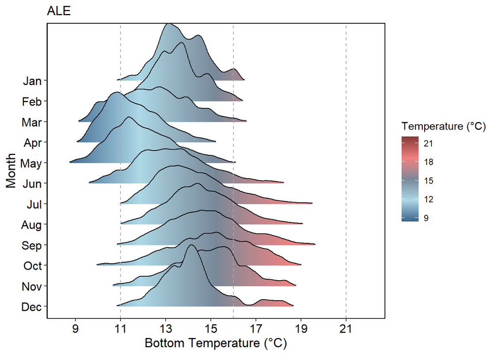

```
## [1] "ARQ"
```

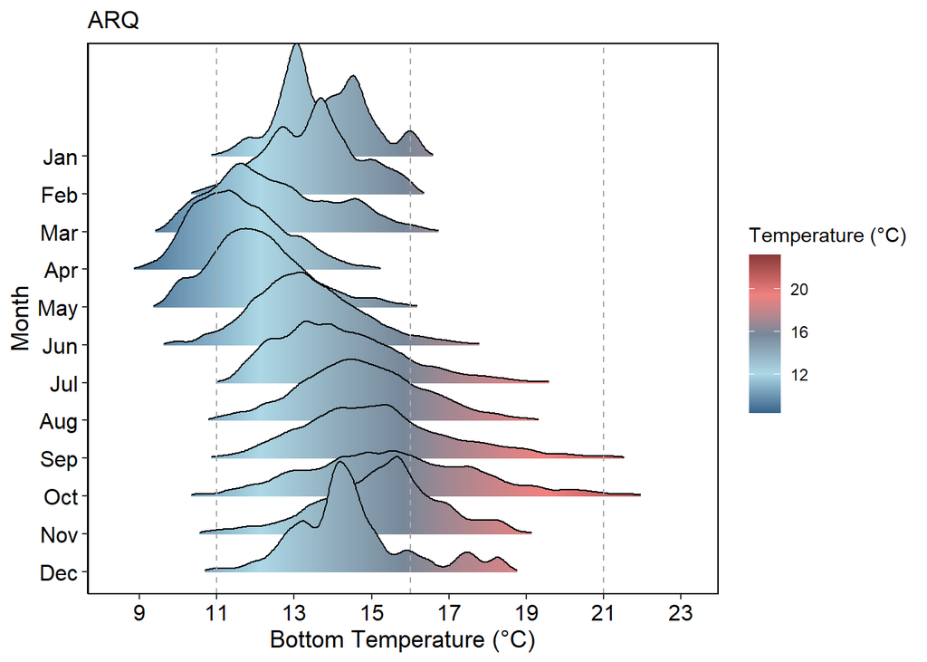

```
## [1] "CAR"
```

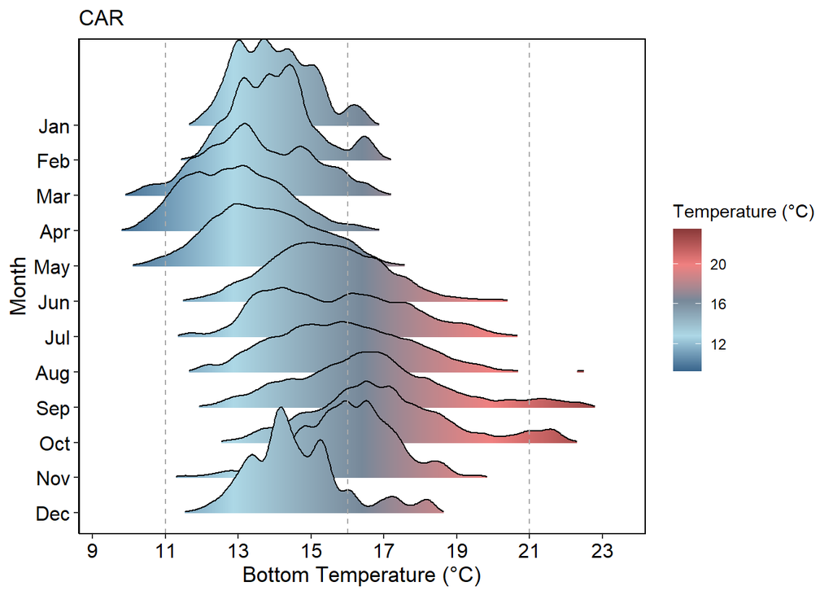

```
## [1] "MKO"
```

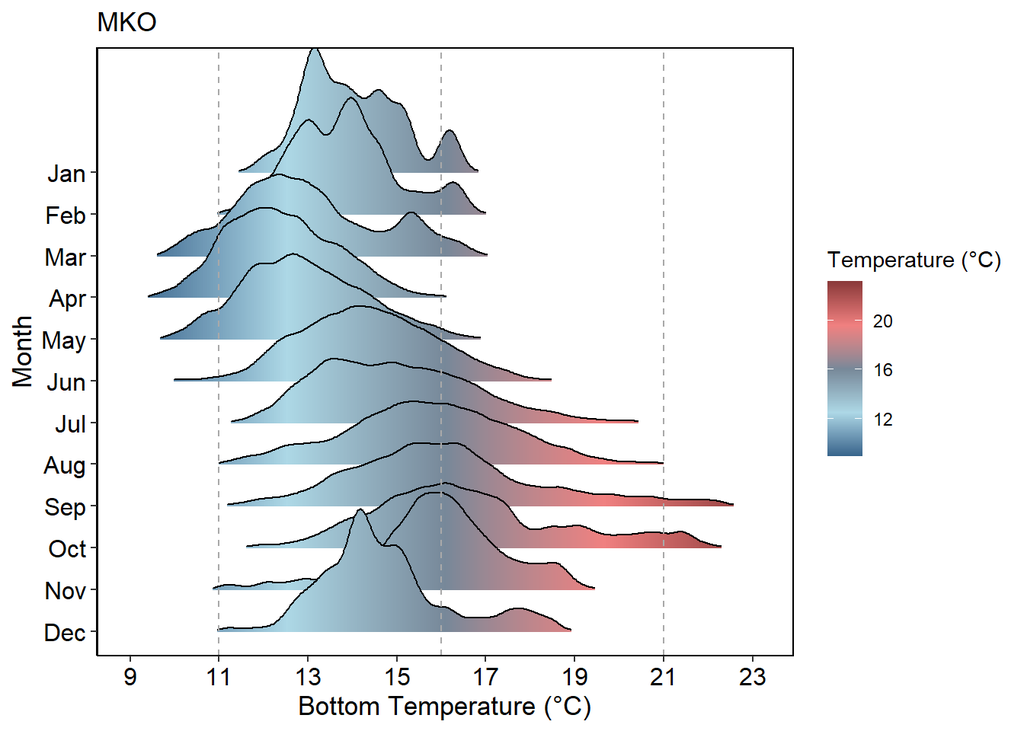

```
## [1] "NAP"
```

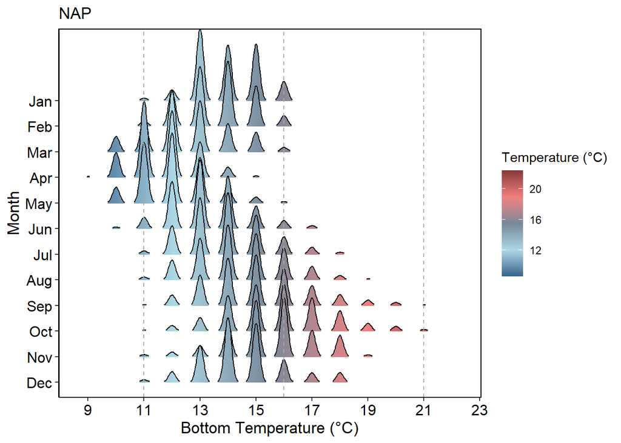

```r
for(i in 1:length(unique_sites)) {

  lter_site <- unique_sites[i]

  print(lter_site)

  subset <- cleaned_temp_data %>%
    filter(site == lter_site)

  densityridges_plot <- ggplot(subset, aes(x = Temp_bot, y = month_name, fill = ..x..)) +
  geom_density_ridges_gradient(scale = 3, rel_min_height = 0.01) +
  geom_vline(xintercept = 11, linetype = "dashed", color = "darkgray") +
  geom_vline(xintercept = 16, linetype = "dashed", color = "darkgray") +
  geom_vline(xintercept = 21, linetype = "dashed", color = "darkgray") +
  scale_fill_gradientn(colors = c("steelblue4", "lightblue", "lightslategray", "lightcoral", "indianred4"), name = "Temperature (°C)") +
  scale_x_continuous(breaks = seq(9, 26, by = 2)) +
  labs(x = "Bottom Temperature (°C)", y = "Month", title = lter_site) +
  theme_classic() +
  theme(axis.text = element_text(color = "black", size = 12),
        axis.title = element_text(size = 13),
        panel.border = element_rect(colour = "black", fil = NA, size = 0.7),
        strip.background = element_rect(fill = "white"),
        strip.text = element_text(size = 12))

  plot(densityridges_plot)

}
```

Amelia’s work ##################################

#Get average temperature for each date

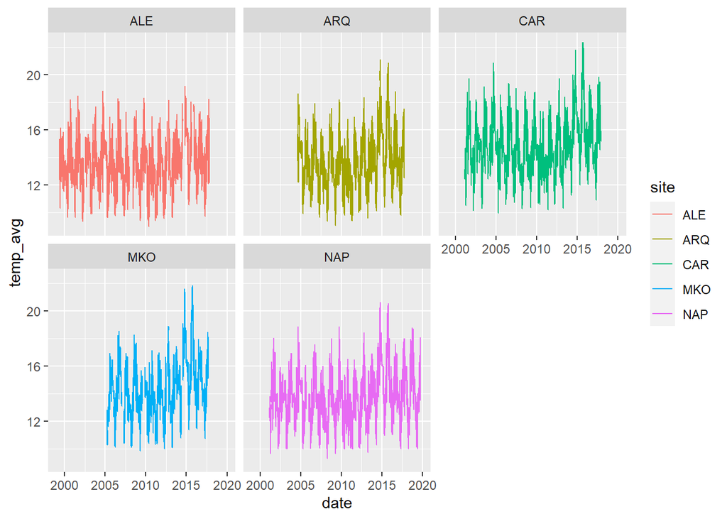

```r
temp_avg <- temp_data %>%
  mutate(date = date(date_time),
         mo_yr = yearmonth(date),
         mo = month(mo_yr, label = TRUE)) %>%
  group_by(date, year, mo, site) %>%
  summarize(temp_avg = mean(Temp_bot)) %>%
  ungroup()

#plot average temperature for each month for each site
ggplot(data=temp_avg, aes(x=date, y=temp_avg, color=site)) +
  geom_line() +
  facet_wrap(~site)
```

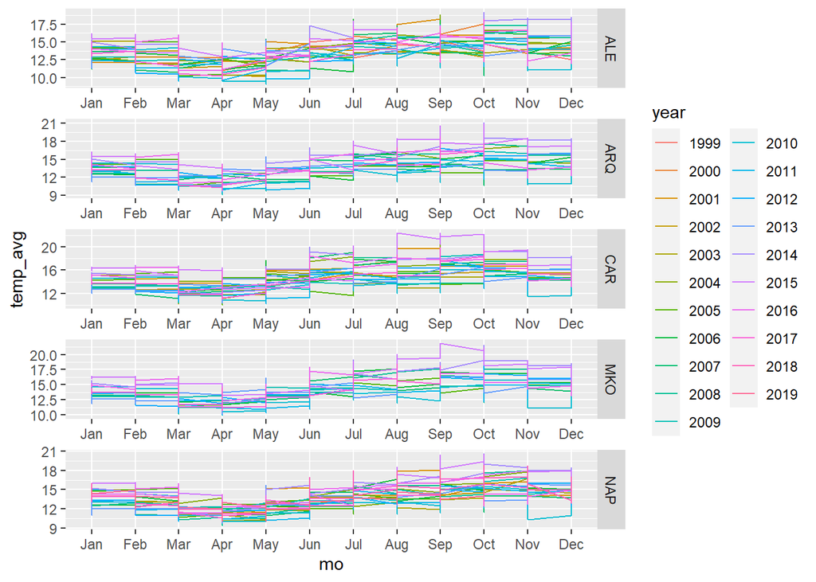

```r
ggsave(here("bottom-temp", "amelia", "fig1.png"), height=5, width=8)
#season plot
ggplot(data=temp_avg, aes(x=mo, y=temp_avg, group=year)) +
  geom_line(aes(color=year)) +
  facet_wrap(~site,
             ncol=1,
             scales="free",
             strip.position = "right")
```

Make Naples a timeseries df

```r
nap_ts_prep <- cleaned_temp_data %>%
  group_by(site, year, month, day) %>%
  summarize(temp = mean(Temp_bot)) %>% #get average temperature for each date
  ungroup() %>%
  unite(date_new, year:day, sep="/") %>% #make a date column in a format to easily run as.Date next
  mutate(date = as.Date(date_new, format="%Y/%m/%d")) %>%  #tell R this is a date
  filter(site=="NAP") %>%
  drop_na() #drop NA values

#coerce to ts df
nap_ts = ts(data = nap_ts_prep$temp,
                    start = c(1999,1),
                    frequency = 365.24)

#summarize
summary(nap_ts)
```

```
##    Min. 1st Qu.  Median    Mean 3rd Qu.    Max.
##   9.306  12.542  13.806  13.817  15.000  20.611
```

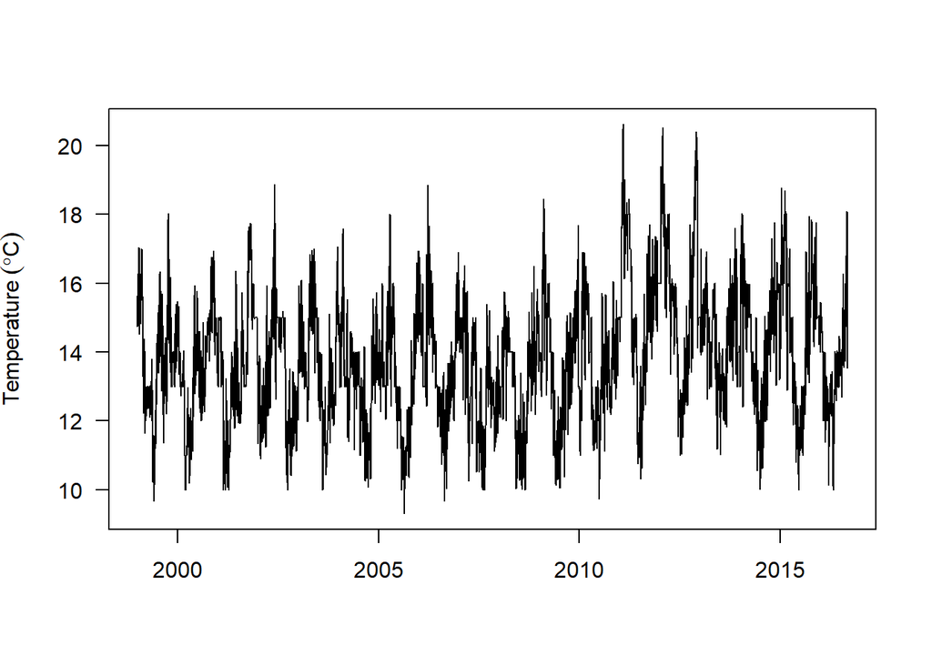

```r
#visualize
nap_ts %>% plot(xlab = "", las = 1,
                  ylab = expression(Temperature~(degree*C)))
```

From https://semba-blog.netlify.app/02/22/2019/exploring-time-series-data-in-r/#tab:tab4 ID shifts in mean/variance at Naples

```r
library(changepoint)

daily.changepoints = nap_ts %>%
  changepoint::cpt.meanvar()

daily.changepoints %>% summary()
```

```
## Created Using changepoint version 2.2.2
## Changepoint type      : Change in mean and variance
## Method of analysis    : AMOC
## Test Statistic  : Normal
## Type of penalty       : MBIC with value, 26.31737
## Minimum Segment Length : 2
## Maximum no. of cpts   : 1
## Changepoint Locations : 4370
```

There are two segments with one change point.

```r
library(kableExtra)

daily.changepoints %>%
  param.est() %>%
  data.frame() %>%
  mutate(segment = c("First", "Second")) %>% select(segment, mean, variance) %>%
  kableExtra::kable(format = "html", digits = 2,
                    caption = "Mean and variance of change point for daily sst",
                    col.names = c("Segment", "Mean", "Variance")) %>%
  kableExtra::column_spec(column = 1:3, width = "3cm") %>%
  kableExtra::add_header_above(c("", "Parameters" = 2))
```

Mean and variance of change point for daily sst

| Segment | Parameters Mean | Parameters Variance |
| --- | --- | --- |
| First | 13.45 | 2.54 |
| Second | 14.59 | 3.81 |

The first segment had a lower mean bottom temperature and lower variance in bottom temperature.

Let’s plot the breakpoint

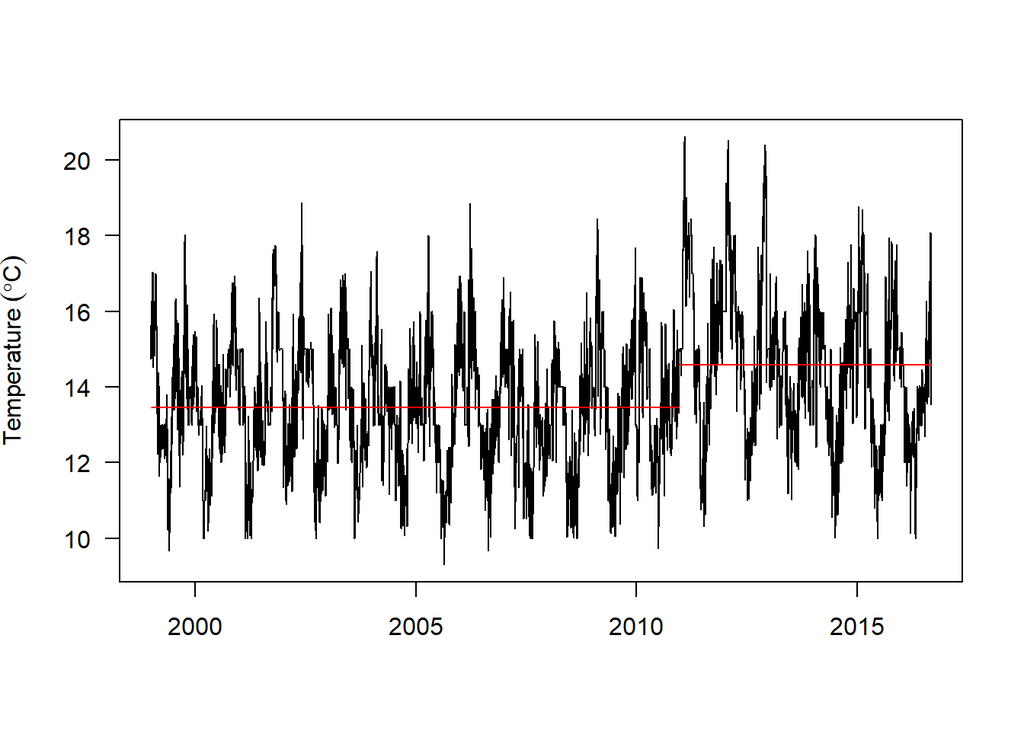

```r
daily.changepoints %>%
  changepoint::plot(xlab = "", ylab = expression(Temperature~(degree*C)), las = 1)
```

Looks like 2010 was the year the change point occurred *for days*.

```r
#isolate the exact date for changepoint
#create monthly data set vector from January 1999 to December 2017
analysis.day = seq(dmy(010199), dmy(311217), by = "day")
analysis.day[cpts(daily.changepoints)]
```

```
## [1] "2010-12-18"
```

December 18, 2010 to be exact

Now, do the same for months (and years) Month:

```r
nap_ts_mo_prep <- cleaned_temp_data %>%
  group_by(site, year, month) %>%
  summarize(temp = mean(Temp_bot)) %>% #get average temperature for each date
  ungroup() %>%
  arrange(year, month) %>%
  filter(site=="NAP") %>%
  drop_na() #drop NA values

#coerce to ts df
nap_ts_mo = ts(data = nap_ts_mo_prep$temp,
                    start = c(1999,1),
                    frequency = 12)

#summarize
summary(nap_ts_mo)
```

```
##    Min. 1st Qu.  Median    Mean 3rd Qu.    Max.
##   10.72   12.69   13.95   13.93   15.06   18.89
```

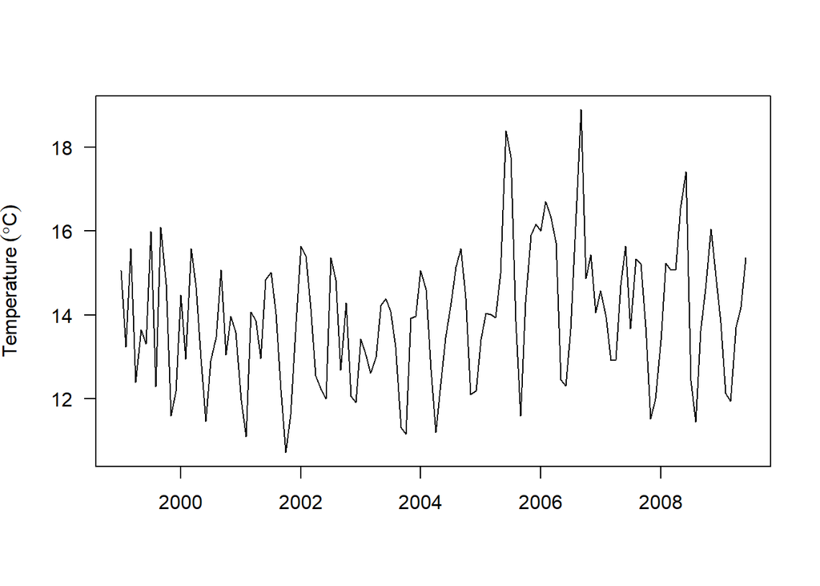

```r
#visualize
nap_ts_mo %>% plot(xlab = "", las = 1,
                  ylab = expression(Temperature~(degree*C)))
```

```r
#ID breakpoints
daily.changepoints_mo = nap_ts_mo %>%
  changepoint::cpt.meanvar()

daily.changepoints_mo %>% summary()
```

```
## Created Using changepoint version 2.2.2
## Changepoint type      : Change in mean and variance
## Method of analysis    : AMOC
## Test Statistic  : Normal
## Type of penalty       : MBIC with value, 14.50885
## Minimum Segment Length : 2
## Maximum no. of cpts   : 1
## Changepoint Locations : 125
```

```r
daily.changepoints_mo %>%
  param.est() %>%
  data.frame() %>%
  mutate(segment = c("First", "Second")) %>% select(segment, mean, variance) %>%
  kableExtra::kable(format = "html", digits = 2,
                    caption = "Mean and variance of change point for daily sst",
                    col.names = c("Segment", "Mean", "Variance")) %>%
  kableExtra::column_spec(column = 1:3, width = "3cm") %>%
  kableExtra::add_header_above(c("", "Parameters" = 2))
```

Mean and variance of change point for daily sst

| Segment | Parameters Mean | Parameters Variance |
| --- | --- | --- |
| First | 13.92 | 2.55 |
| Second | 15.36 | NA |

Two segments, first has lower mean temperature than the second

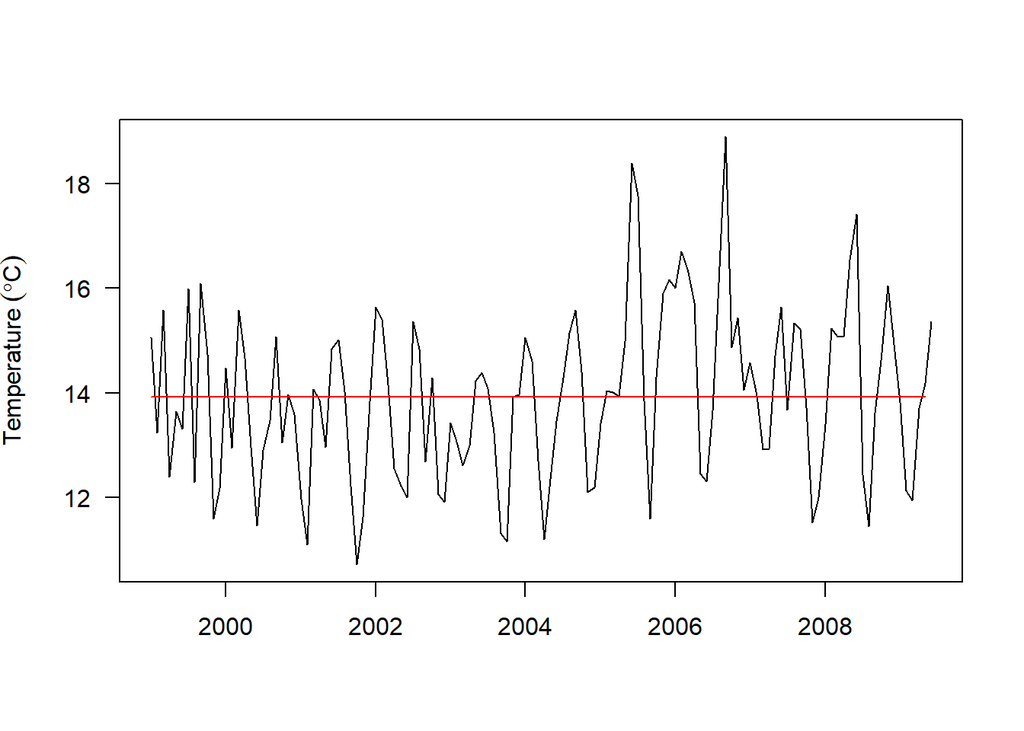

```r
#plot the breakpoint
daily.changepoints_mo %>%
  changepoint::plot(xlab = "", ylab = expression(Temperature~(degree*C)), las = 1)
```

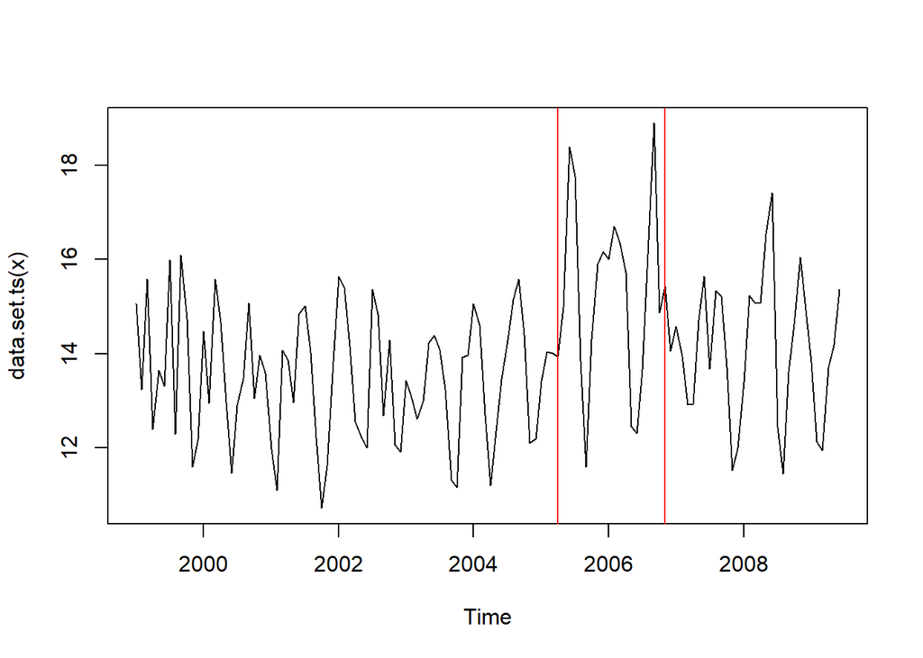

```r
#notice that change point is not noticeable, so run it again using a nonparametric function

library(changepoint.np)
daily.changepoints_mo_np = nap_ts_mo %>% changepoint.np::cpt.np()

daily.changepoints_mo_np %>% changepoint::plot()
```

```r
#isolate the exact dates for changepoints
#create monthly data set vector from January 1999 to December 2009
analysis.month = seq(dmy(010199), dmy(311209), by = "month")
analysis.month[cpts(daily.changepoints_mo_np)]
```

```
## [1] "2005-04-01" "2006-11-01"
```

Change occurred April 2005 and again on November 2006… anything odd about those dates?

Make a Naples heatmap

```r
library(oce)

#clean up the data a bit more
day_nap <- cleaned_temp_data %>%
  group_by(site, year, month, day) %>%
  summarize(temp = mean(Temp_bot)) %>%
  ungroup() %>%
  unite(date_new, year:day, sep="/") %>% #make a date column in a format to easily run as.Date next
  mutate(date = as.Date(date_new, format="%Y/%m/%d")) %>%  #tell R this is a date
  select(date, site, temp) %>%
  filter(site=="NAP", #only look at Naples
         !is.na(temp)) #remove NAs

#define days and years relevant to data
days = 1:366
years = 2001:2019

nap_matrix = matrix(day_nap$temp, nrow = length(days))
```

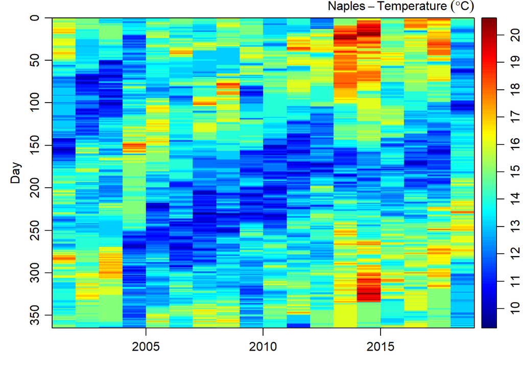

```r
imagep(x = years, y = days, z = nap_matrix %>%
         t(),
       filledContour = F,
       ylim = c(365,0),
       ylab = "Day",
       col = oceColors9A(120),
       zlab = expression(Naples-Temperature~(degree *C)))
```

More resources: Change point detection https://rpubs.com/richkt/269908

To do: - figure out if ts conversion deletes or fills in missing data - breakpoint analysis for years - use coefficient of variation to calculate cycle for each site to answer “what is an average day at [site]?” - compare models and anomalies at each site to assess differences between sites